# Solucion

### Modelo con la serie temporal generada por la hipótesis 4

Como se puede ver en el gráfico PACF, hay 4 valores que están fuera del rango, por que el orden de p es 4. Respecto al orden de q, solo hay tres valores que sobrepasan ese rango, por lo que será 3.

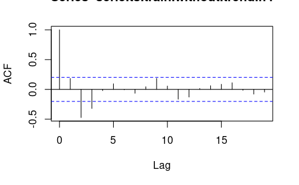

```r
acf(serie.ts.train.without.trend.h4)
```

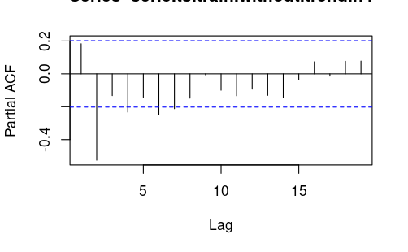

```r
pacf(serie.ts.train.without.trend.h4)
```

```r
arima.model.h4 <- arima(
    serie.ts.train.without.trend.h4,
    order = c(4, 0, 3)
)

valoresAjustados.h4 <- serie.ts.train.without.trend.h4 + arima.model.h4$residuals + trend.estimated.train.h4
predictions.h4 <- predict(arima.model.h4, n.ahead = 2)$pred + trend.estimated.test.h4

# Representación de los valores ajustados y la predicción
plot.ts(
    serie.ts.train,
    xlim=c(1, serie.ts.test.time[length(serie.ts.test.time)])
)
lines(valoresAjustados.h4, col="blue")
```

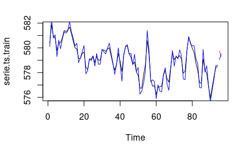

```r
lines(serie.ts.test.time, serie.ts.test, col="red")
lines(serie.ts.test.time, predictions.h4, col="blue")
```

A continuación se comprueba la bondad del modelo construido. Para ello se va a ejecutar el test estadístico de Box-Pierce (para comprobar si los residuos son aleatorios) y los test estadísticos de Shapiro-wilk y jarque-bera (para comprobar si los residuos siguen una distribución normal). Si en alguno de estos test estadísticos se rechaza la hipótesis nula, estamos ante un mal modelo.

```r
Box.test(arima.model.h4$residuals)
```

```
    Box-Pierce test

data:  arima.model.h4$residuals
X-squared = 0.01213, df = 1, p-value = 0.9123
```

```r
jarque.bera.test(arima.model.h4$residuals)
```

```
    Jarque Bera Test

data:  arima.model.h4$residuals
X-squared = 1.3133, df = 2, p-value = 0.5186
```

```r
shapiro.test(arima.model.h4$residuals)
```

```
    Shapiro-Wilk normality test

data:  arima.model.h4$residuals
W = 0.99019, p-value = 0.7193
```

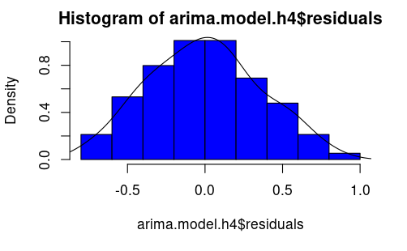

```r
hist(arima.model.h4$residuals, col="blue", prob=T)
lines(density(arima.model.h4$residuals))
```

Finalmente, para tener una serie de métricas que permitan comparar varios modelos, se va a calcular el error cuadrático medio para train y test además del criterio de información de Akaike para el modelo. Las tres métricas son a minimizar.

```r
errorTrain.h4 <- sqrt(mean((valoresAjustados.h4 - serie.ts.train)^2))
errorTest.h4 <- sqrt(mean((predictions.h4 - serie.ts.test)^2))
aic.h4 <- AIC(arima.model.h4)
cat("RMSE train:", errorTrain.h4, "\nRMSE test:", errorTest.h4, "\nAIC:", aic.h4)
```

```
RMSE train: 0.356463
RMSE test: 0.5018412
AIC: 96.45114
```

### Modelo con la serie temporal generada por la hipótesis 5

Como se puede ver en el gráfico PACF, hay 5 valores que están fuera del rango, por que el orden de p es 5. Respecto al orden de q, solo hay dos valores que sobrepasan ese rango, por lo que será 2.

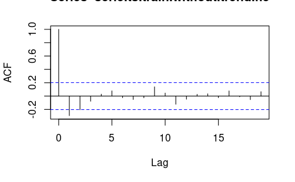

```r
acf(serie.ts.train.without.trend.h5)
```

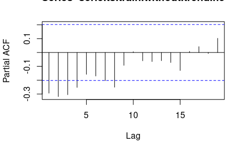

```r
pacf(serie.ts.train.without.trend.h5)
```

```r
arima.model.h5 <- arima(
    serie.ts.train.without.trend.h5,
    order = c(5, 0, 2)
)

valoresAjustados.h5 <- serie.ts.train.without.trend.h5 + arima.model.h5$residuals + trend.estimated.train.h5
predictions.h5 <- predict(arima.model.h5, n.ahead = 2)$pred + trend.estimated.test.h5

# Representación de los valores ajustados y la predicción
plot.ts(
    serie.ts.train,
    xlim=c(1, serie.ts.test.time[length(serie.ts.test.time)])
)
lines(valoresAjustados.h5, col="blue")
```

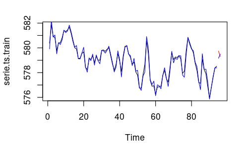

```r
lines(serie.ts.test.time, serie.ts.test, col="red")
lines(serie.ts.test.time, predictions.h5, col="blue")
```

A continuación se comprueba la bondad del modelo construido. Para ello se va a ejecutar el test estadístico de Box-Pierce (para comprobar si los residuos son aleatorios) y los test estadísticos de Shapiro-wilk y jarque-bera (para comprobar si los residuos siguen una distribución normal). Si en alguno de estos test estadísticos se rechaza la hipótesis nula, estamos ante un mal modelo.

```r
Box.test(arima.model.h5$residuals)
```

```
    Box-Pierce test

data:  arima.model.h5$residuals
X-squared = 0.0016413, df = 1, p-value = 0.9677
```

```r
jarque.bera.test(arima.model.h5$residuals)
```

```
    Jarque Bera Test

data:  arima.model.h5$residuals
X-squared = 0.48786, df = 2, p-value = 0.7835
```

```r
shapiro.test(arima.model.h5$residuals)
```

```
    Shapiro-Wilk normality test

data:  arima.model.h5$residuals
W = 0.98466, p-value = 0.3416
```

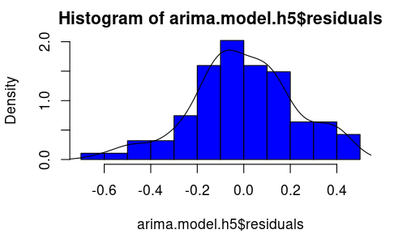

```r
hist(arima.model.h5$residuals, col="blue", prob=T)
lines(density(arima.model.h5$residuals))
```

Finalmente, para tener una serie de métricas que permitan comparar varios modelos, se va a calcular el error cuadrático medio para train y test además del criterio de información de Akaike para el modelo. Las tres métricas son a minimizar.

```r
errorTrain.h5 <- sqrt(mean((valoresAjustados.h5 - serie.ts.train)^2))
errorTest.h5 <- sqrt(mean((predictions.h5 - serie.ts.test)^2))
aic.h5 <- AIC(arima.model.h5)
cat("RMSE train:", errorTrain.h5, "\nRMSE test:", errorTest.h5, "\nAIC:", aic.h5)
```

```
RMSE train: 0.2209572
RMSE test: 0.4284353
AIC: 11.25927
```

### Modelo con la serie temporal generada por la hipótesis 6

Como se puede ver en el gráfico PACF, hay 4 valores que están fuera del rango, por que el orden de p es 4. Respecto al orden de q, solo hay tres valores que sobrepasan ese rango, por lo que será 3.

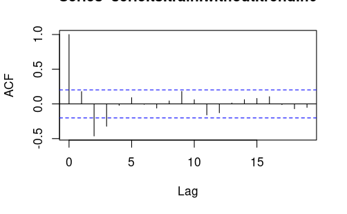

```r
acf(serie.ts.train.without.trend.h6)
```

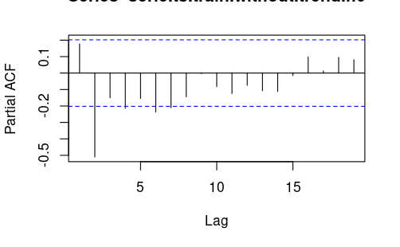

```r
pacf(serie.ts.train.without.trend.h6)
```

```r
arima.model.h6 <- arima(
    serie.ts.train.without.trend.h6,
    order = c(4, 0, 3)
)

valoresAjustados.h6 <- serie.ts.train.without.trend.h6 + arima.model.h6$residuals + trend.estimated.train.h6
predictions.h6 <- predict(arima.model.h6, n.ahead = 2)$pred + trend.estimated.test.h6

# Representación de los valores ajustados y la predicción
plot.ts(
    serie.ts.train,
    xlim=c(1, serie.ts.test.time[length(serie.ts.test.time)])
)
lines(valoresAjustados.h6, col="blue")
```

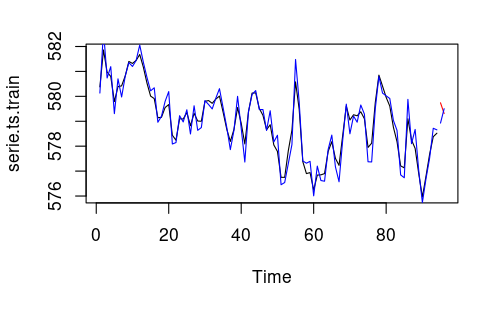

```r
lines(serie.ts.test.time, serie.ts.test, col="red")
lines(serie.ts.test.time, predictions.h6, col="blue")
```

A continuación se comprueba la bondad del modelo construido. Para ello se va a ejecutar el test estadístico de Box-Pierce (para comprobar si los residuos son aleatorios) y los test estadísticos de Shapiro-wilk y jarque-bera (para comprobar si los residuos siguen una distribución normal). Si en alguno de estos test estadísticos se rechaza la hipótesis nula, estamos ante un mal modelo.

```r
Box.test(arima.model.h6$residuals)
```

```
    Box-Pierce test

data:  arima.model.h6$residuals
X-squared = 0.03948, df = 1, p-value = 0.8425
```

```r
jarque.bera.test(arima.model.h6$residuals)
```

```
    Jarque Bera Test

data:  arima.model.h6$residuals
X-squared = 0.789, df = 2, p-value = 0.674
```

```r
shapiro.test(arima.model.h6$residuals)
```

```
    Shapiro-Wilk normality test

data:  arima.model.h6$residuals
W = 0.99104, p-value = 0.7825
```

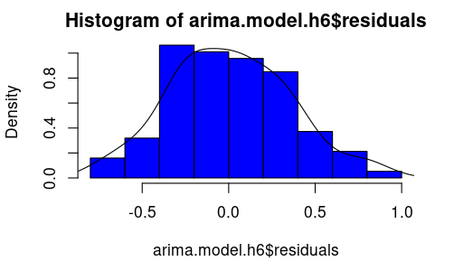

```r
hist(arima.model.h6$residuals, col="blue", prob=T)
lines(density(arima.model.h6$residuals))
```

Finalmente, para tener una serie de métricas que permitan comparar varios modelos, se va a calcular el error cuadrático medio para train y test además del criterio de información de Akaike para el modelo. Las tres métricas son a minimizar.

```r
errorTrain.h6 <- sqrt(mean((valoresAjustados.h6 - serie.ts.train)^2))
errorTest.h6 <- sqrt(mean((predictions.h6 - serie.ts.test)^2))
aic.h6 <- AIC(arima.model.h6)
cat("RMSE train:", errorTrain.h6, "\nRMSE test:", errorTest.h6, "\nAIC:", aic.h6)
```

```
RMSE train: 0.3473021
RMSE test: 0.5905708
AIC: 95.5339
```

### Resumen modelos

| Modelo | Orden | ¿Box-pierce? | ¿Jarque-bera? | ¿Shafiro-wilk? | RMSE Train | RMSE Test | AIC |
| --- | --- | --- | --- | --- | --- | --- | --- |
| Modelo 1 | 6, 0, 2 | Sí | Sí | Sí | 0.2289644 | 1.4877722 | 16.04387 |
| Modelo 2 | 3, 0, 3 | Sí | Sí | Sí | 0.3663725 | 2.7371265 | 100.10309 |
| Modelo 3 | 6, 0, 3 | Sí | Sí | Sí | 0.2179291 | 0.4112252 | 12.93143 |
| Modelo 4 | 4, 0, 3 | Sí | Sí | Sí | 0.3564630 | 0.5018412 | 96.45114 |
| Modelo 5 | 5, 0, 2 | Sí | Sí | Sí | 0.2209572 | 0.4284353 | 11.25927 |
| Modelo 6 | 4, 0, 3 | Sí | Sí | Sí | 0.3473021 | 0.5905708 | 95.53390 |

Como se puede ver en esta tabla, se ha hecho un resumen de los distintos modelos que se han realizado especificando el orden que se ha establecido y el resultado de los test estadísticos y de las métricas que se han obtenido.

Revisando los RMSE que se han obtenido en entrenamiento y test, el mejor modelo de todos es el modelo 3 (que se ha entrenado teniendo en cuenta que la tendencia se ha modelado según la hipótesis 3). Aunque es el segundo modelo más simple según el criterio de información de Akaike, es el mejor de todos en predecir los siguientes dos valores además de ajustarse correctamente a los datos de entrenamiento.

Por lo tanto, se va a utilizar la configuración del modelo 3 para predecir los dos siguientes valores de la serie, objetivo principal de esta práctica.

## Predicción de los dos siguientes valores

### Tendencia

```r
trend.estimated <- ma.series(
    serie.ts, k=1
)

serie.ts.time <- 1:length(serie.ts)

first_n_lm <- lm(serie.ts[1:(1+2)] ~ serie.ts.time[1:(1+2)])
trend.estimated[1] <- first_n_lm$fitted.values[1]

last_n_lm <- lm(
    serie.ts[(length(serie.ts) - 1 - 1):length(serie.ts)] ~ serie.ts.time[(length(serie.ts) - 1 - 1):length(serie.ts)]
)
trend.estimated[length(serie.ts)] <- last_n_lm$fitted.values[3]

trend.estimated.prediction <- last_n_lm$coefficients[1] + c(97, 98)*last_n_lm$coefficients[2]

serie.ts.without.trend <- serie.ts - trend.estimated
```

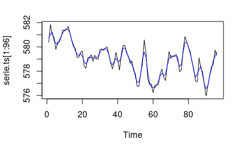

```r
plot.ts(serie.ts[1:96], xlim=c(1, length(serie.ts)))
lines(1:length(serie.ts), trend.estimated, col="blue")
```

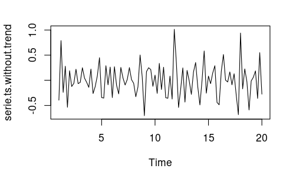

```r
plot.ts(serie.ts.without.trend)
```

### ARIMA

```r
arima.model.final <- arima(
    serie.ts.without.trend,
    order = c(6, 0, 3)
)

final.predictions <- predict(arima.model.final, n.ahead = 2)$pred
```

### Obtención de los valores y gráfica final

Las predicciones de los dos valores siguientes son: 580.1493 y 580.4179

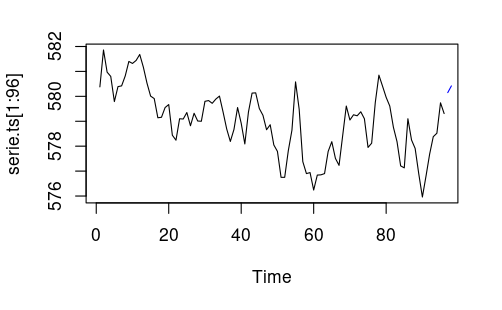

```r
predictions.with.trend <- final.predictions + trend.estimated.prediction

plot.ts(
    serie.ts[1:96]
)
lines(97:98, predictions.with.trend, col="blue")
```